# Homework: Manipulating Data

Firstname Lastname

## Instructions

When you are finished with the assignment:

1. Save the file as 05_Lastname_Firstname.Rmd and compile it
2. Commit the Rmd file and corresponding html file to your homework git repo
3. Push the commit to github
4. Locate the Rmd file on github and click on the SHA link for the file
5. Paste the url of the resulting page into Canvas to submit your assignment.

Your assignment must compile on a different computer as long as the saspath is set correctly for that machine. This means you will need to use a local file path when you read the data in via R (and SAS).

## Poetry? The `R`aven

(In case it isn’t obvious, do this part in R)

> “The Raven” is a narrative poem by American writer Edgar Allan Poe. First published in January 1845, the poem is often noted for its musicality, stylized language, and supernatural atmosphere. Sitting on a bust of Pallas, the raven seems to further distress the protagonist with its constant repetition of the word “Nevermore”. The poem makes use of folk, mythological, religious, and classical references. – [Wikipedia](https://en.wikipedia.org/wiki/The_Raven)

Read in the lines of text in “The Raven” and write code to do the following tasks:

1. Create a tibble with a column that contains the lines of the poem (leave the blank lines in for now)
2. Count the number of words in each line. Do you see any patterns?
3. Can you use this information to create a variable with stanza numbers?
4. Create a column with line numbers (within each stanza)
5. Split the lines of the poem into words (you can discard punctuation). Is there any discernible pattern?

If you are interested, you can use the `syllables` function in the R package `quanteda` to get syllable counts and continue the exploration.

Hints: `stringr` is the package for text manipulation. `str_split` will split lines into words. You may also find `unnest` from the `tidyr` package to be useful

### Initial processing

```r
step1 <- tibble(lines = readLines("the_raven_poe.txt")) %>%
  # Create line number
  mutate(line_no = 1:n())

knitr::kable(head(step1, 10))
```

| lines | line_no |
| --- | --- |
| Once upon a midnight dreary, while I pondered, weak and weary, | 1 |
| Over many a quaint and curious volume of forgotten lore— | 2 |
| While I nodded, nearly napping, suddenly there came a tapping, | 3 |
| As of some one gently rapping, rapping at my chamber door. | 4 |
| “’Tis some visitor,” I muttered, “tapping at my chamber door— | 5 |
| Only this and nothing more.” | 6 |
|  | 7 |
| Ah, distinctly I remember it was in the bleak December; | 8 |
| And each separate dying ember wrought its ghost upon the floor. | 9 |
| Eagerly I wished the morrow;—vainly I had sought to borrow | 10 |

It would also be reasonable to use only the non-blank lines as line numbers.

```r
step1_alt <- tibble(lines = readLines("the_raven_poe.txt")) %>%
  mutate(
    # Count the cumulative number of lines which aren't blanks
    line_no = cumsum(lines != ""),
    # Replace the counts of blank lines with NA
    line_no = ifelse(lines == "", NA, line_no))

knitr::kable(head(step1_alt, 10))
```

| lines | line_no |
| --- | --- |
| Once upon a midnight dreary, while I pondered, weak and weary, | 1 |
| Over many a quaint and curious volume of forgotten lore— | 2 |
| While I nodded, nearly napping, suddenly there came a tapping, | 3 |
| As of some one gently rapping, rapping at my chamber door. | 4 |
| “’Tis some visitor,” I muttered, “tapping at my chamber door— | 5 |
| Only this and nothing more.” | 6 |
|  | NA |
| Ah, distinctly I remember it was in the bleak December; | 7 |
| And each separate dying ember wrought its ghost upon the floor. | 8 |
| Eagerly I wished the morrow;—vainly I had sought to borrow | 9 |

Either option is ok for our purposes.

```r
step2 <- step1 %>%
  mutate(n_words = str_count(lines, " "),
         # If there are any spaces present, there's a word on each side of the
         # space, so we need to add 1 to get a good count...
         n_words = ifelse(n_words > 0, n_words + 1, n_words))

knitr::kable(head(step2, 10))
```

| lines | line_no | n_words |
| --- | --- | --- |
| Once upon a midnight dreary, while I pondered, weak and weary, | 1 | 11 |
| Over many a quaint and curious volume of forgotten lore— | 2 | 10 |
| While I nodded, nearly napping, suddenly there came a tapping, | 3 | 10 |
| As of some one gently rapping, rapping at my chamber door. | 4 | 11 |
| “’Tis some visitor,” I muttered, “tapping at my chamber door— | 5 | 10 |
| Only this and nothing more.” | 6 | 5 |
|  | 7 | 0 |
| Ah, distinctly I remember it was in the bleak December; | 8 | 10 |
| And each separate dying ember wrought its ghost upon the floor. | 9 | 11 |
| Eagerly I wished the morrow;—vainly I had sought to borrow | 10 | 10 |

A more sophisticated option would be to look at `?str_count` and see that there is a `boundary()` function that can be used to count words.

```r
step2_alt <- step1 %>%
  mutate(n_words = str_count(lines, boundary("word")))

knitr::kable(head(step2_alt, 10))
```

| lines | line_no | n_words |
| --- | --- | --- |
| Once upon a midnight dreary, while I pondered, weak and weary, | 1 | 11 |
| Over many a quaint and curious volume of forgotten lore— | 2 | 10 |
| While I nodded, nearly napping, suddenly there came a tapping, | 3 | 10 |
| As of some one gently rapping, rapping at my chamber door. | 4 | 11 |
| “’Tis some visitor,” I muttered, “tapping at my chamber door— | 5 | 10 |
| Only this and nothing more.” | 6 | 5 |
|  | 7 | 0 |
| Ah, distinctly I remember it was in the bleak December; | 8 | 10 |
| And each separate dying ember wrought its ghost upon the floor. | 9 | 11 |
| Eagerly I wished the morrow;—vainly I had sought to borrow | 10 | 11 |

As blank lines between stanzas indicate a break, we can look for `n_words == 0` to show the stanza breaks. If we then use cumsum() (cumulative sum) over the binary variable `n_words == 0`, then we’ll have 0, 0, 0, 0, 0, 0, 1, 1, 1, 1, 1, 1, 1, 2, 2, 2, 2, 2, 2, … a stanza count starting at 0.

```r
step3 <- step2 %>%
  mutate(stanza = cumsum(n_words == 0) + 1)

knitr::kable(head(step3, 10))
```

| lines | line_no | n_words | stanza |
| --- | --- | --- | --- |
| Once upon a midnight dreary, while I pondered, weak and weary, | 1 | 11 | 1 |
| Over many a quaint and curious volume of forgotten lore— | 2 | 10 | 1 |
| While I nodded, nearly napping, suddenly there came a tapping, | 3 | 10 | 1 |
| As of some one gently rapping, rapping at my chamber door. | 4 | 11 | 1 |
| “’Tis some visitor,” I muttered, “tapping at my chamber door— | 5 | 10 | 1 |
| Only this and nothing more.” | 6 | 5 | 1 |
|  | 7 | 0 | 2 |
| Ah, distinctly I remember it was in the bleak December; | 8 | 10 | 2 |
| And each separate dying ember wrought its ghost upon the floor. | 9 | 11 | 2 |
| Eagerly I wished the morrow;—vainly I had sought to borrow | 10 | 10 | 2 |

Now that we have stanza numbers, we can create a column with line numbers using group_by and row_number() within groups.

We don’t want to count the 0-word lines as actual lines here. So let’s filter them out first!

```r
step4 <- step3 %>%
  filter(n_words > 0) %>%
  group_by(stanza) %>%
  mutate(line = row_number()) %>%
  ungroup()

knitr::kable(head(step4, 10))
```

| lines | line_no | n_words | stanza | line |
| --- | --- | --- | --- | --- |
| Once upon a midnight dreary, while I pondered, weak and weary, | 1 | 11 | 1 | 1 |
| Over many a quaint and curious volume of forgotten lore— | 2 | 10 | 1 | 2 |
| While I nodded, nearly napping, suddenly there came a tapping, | 3 | 10 | 1 | 3 |
| As of some one gently rapping, rapping at my chamber door. | 4 | 11 | 1 | 4 |
| “’Tis some visitor,” I muttered, “tapping at my chamber door— | 5 | 10 | 1 | 5 |
| Only this and nothing more.” | 6 | 5 | 1 | 6 |
| Ah, distinctly I remember it was in the bleak December; | 8 | 10 | 2 | 1 |
| And each separate dying ember wrought its ghost upon the floor. | 9 | 11 | 2 | 2 |
| Eagerly I wished the morrow;—vainly I had sought to borrow | 10 | 10 | 2 | 3 |
| From my books surcease of sorrow—sorrow for the lost Lenore— | 11 | 10 | 2 | 4 |

There are lots of discernible patterns here… it’s poetry, after all. But lets see what we can come up with…

If we use the boundary() function to split on, it will automatically ditch any punctuation for us that’s at the end of a word. So that saves us some time.

```r
step5 <- step4 %>%
  mutate(words = str_split(lines, boundary("word"))) %>%
  unnest(cols = c(words)) %>%
  group_by(line_no) %>%
  mutate(word_no = 1:n(),
         n_char = nchar(words))

knitr::kable(head(step5, 10))
```

| lines | line_no | n_words | stanza | line | words | word_no | n_char |
| --- | --- | --- | --- | --- | --- | --- | --- |
| Once upon a midnight dreary, while I pondered, weak and weary, | 1 | 11 | 1 | 1 | Once | 1 | 4 |
| Once upon a midnight dreary, while I pondered, weak and weary, | 1 | 11 | 1 | 1 | upon | 2 | 4 |
| Once upon a midnight dreary, while I pondered, weak and weary, | 1 | 11 | 1 | 1 | a | 3 | 1 |
| Once upon a midnight dreary, while I pondered, weak and weary, | 1 | 11 | 1 | 1 | midnight | 4 | 8 |
| Once upon a midnight dreary, while I pondered, weak and weary, | 1 | 11 | 1 | 1 | dreary | 5 | 6 |
| Once upon a midnight dreary, while I pondered, weak and weary, | 1 | 11 | 1 | 1 | while | 6 | 5 |
| Once upon a midnight dreary, while I pondered, weak and weary, | 1 | 11 | 1 | 1 | I | 7 | 1 |
| Once upon a midnight dreary, while I pondered, weak and weary, | 1 | 11 | 1 | 1 | pondered | 8 | 8 |
| Once upon a midnight dreary, while I pondered, weak and weary, | 1 | 11 | 1 | 1 | weak | 9 | 4 |
| Once upon a midnight dreary, while I pondered, weak and weary, | 1 | 11 | 1 | 1 | and | 10 | 3 |

We could start out looking at the number of characters per word, though that may or may not tell us anything…

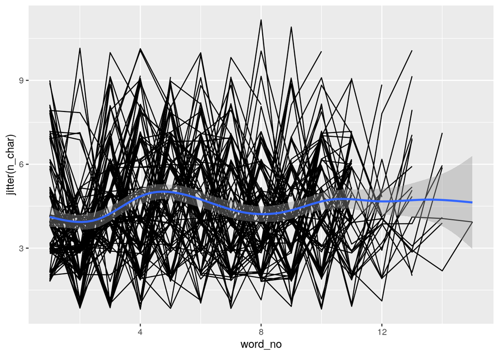

```r
ggplot(step5, aes(x = word_no, y = jitter(n_char), group = line_no)) +
  geom_line() +
  # add a single smooth line for all line numbers
  geom_smooth(aes(x = word_no, y = n_char), inherit.aes = F)
```

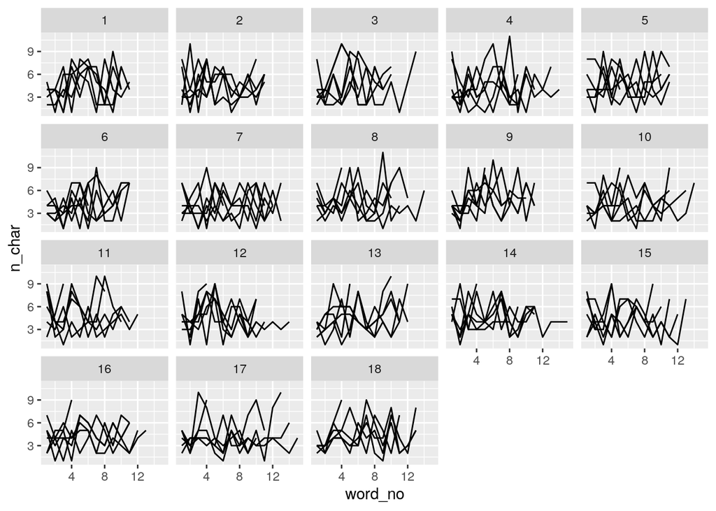

```r
ggplot(step5, aes(x = word_no, y = n_char, group = line)) + geom_line() +
  facet_wrap(~stanza)
```

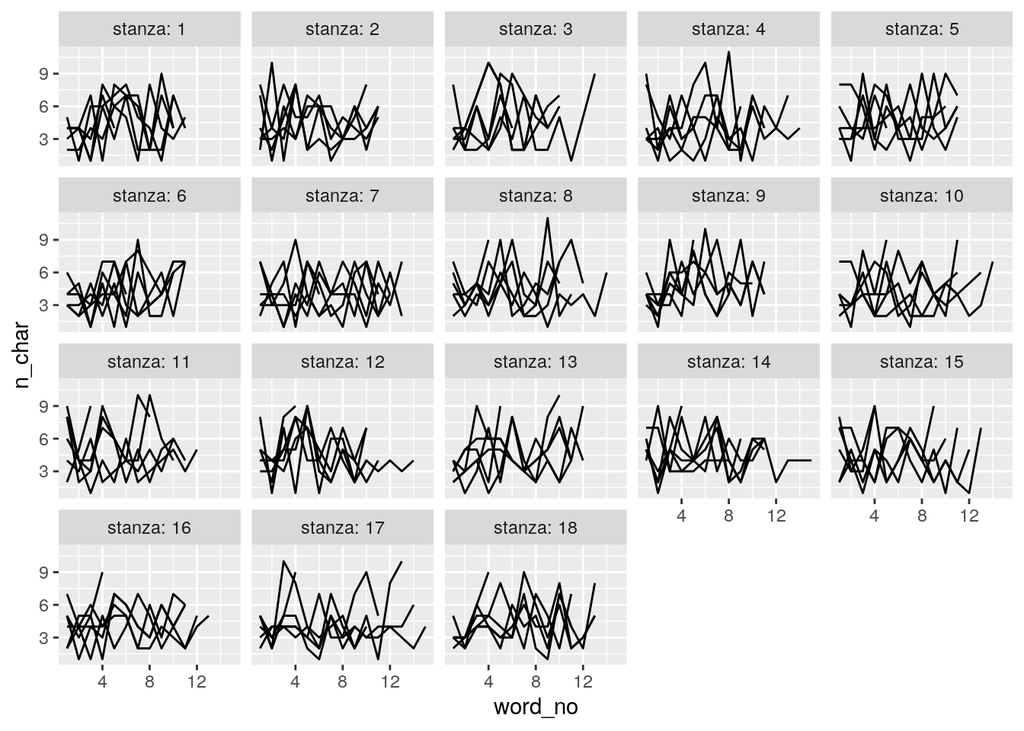

```r
ggplot(step5, aes(x = word_no, y = n_char, group = line)) + geom_line() +
  facet_wrap(~stanza, labeller = label_both)
```

Not a whole lot there. But what if we look for specific motifs? The plots below are similar to ridgeline plots - essentially, each stanza or line is shown on the y-axis, with changes in the height of that line based on the actual variable of interest.

### Looking for patterns

```r
# Here, we make regular expressions to look for specific words; chaining them together with | ensures that if any of these words appear, the regex will be activated.

# I used a poetry analysis/interpretation site to get the ideas for these,
# then combed through the poem to find a list of reasonable words.

religious_regex <- "saint|soul|forgiveness|plutonian|hope|censer|seraphim|angel|tempter|prophet|devil|heaven|aidenn|god|balm|gilead|demon" #aidenn = eden

knowledge_regex <- "pondered|volume|lore|book|wonder|explore|Raven|Pallas|discourse|meaning|relevancy|bust|linking|think|guess|divining"
# The bust of Pallas is a reference to the greek goddess Athena (Pallas Athena),
# the goddess of wisdom/knowledge

death_regex <- "ghost|lost|angels|soul|mortal|grave|ghastly|plutonian|living|dirge"

step5 <- step5 %>%
  # This pattern is anything ending with either ore or oor.
  # We also have to handle o'er, so we use a punctuation flag instead of trying
  # to write a regex that can handle that character.
  mutate(rhymes_with_ore = str_detect(words, "(ore|oor|our|o[[:punct:]]er)$"),
         ing = str_detect(words, "ing$"),
         knowledge = str_detect(words, knowledge_regex),
         religious = str_detect(str_to_lower(words), religious_regex),
         death = str_detect(str_to_lower(words), death_regex)) %>%
  group_by(stanza, line) %>%
  mutate(position = (word_no - 1)/(max(word_no) - 1))
```

#### Rhyme scheme

We’ll start out with the rhyme scheme first, since that’s an easy and obviously recognizable pattern.

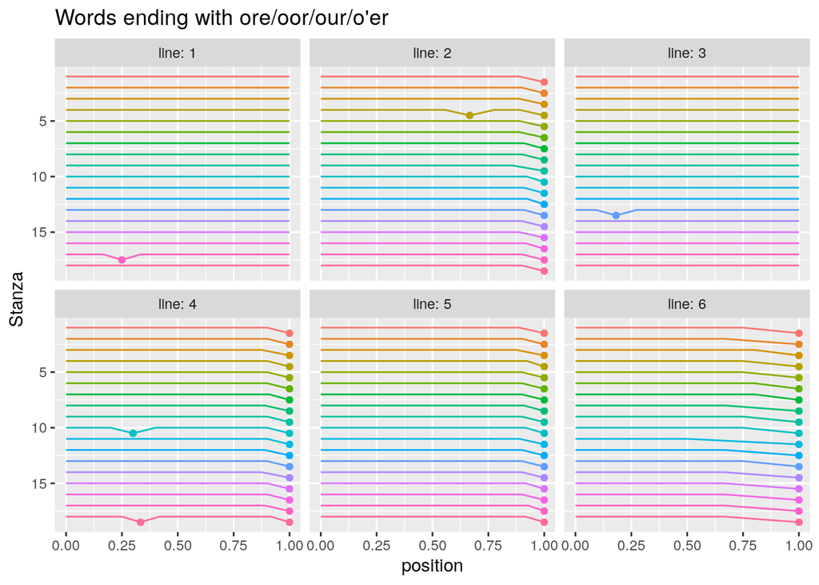

```r
ggplot(step5, aes(x = position, y = stanza + 0.5 * rhymes_with_ore)) +
  geom_line(aes(group = line_no, color = factor(stanza))) +
  geom_point(data = filter(step5, rhymes_with_ore), aes(color = factor(stanza))) +
  facet_wrap(~line, labeller = label_both) +
  ylab("Stanza") +
  ggtitle("Words ending with ore/oor/our/o'er") +
  guides(color = "none") +
  # Reverse the scale so that 1 is at the top
  scale_y_reverse()
```

#### Action words

There are a lot of verbs with “ing” at the end; are there patterns there?

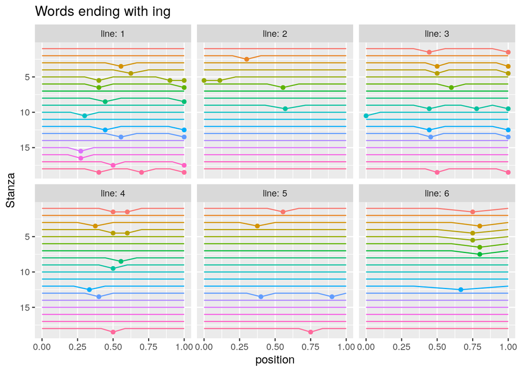

```r
ggplot(step5, aes(x = position, y = stanza + 0.5 * ing)) +
  geom_line(aes(group = line_no, color = factor(stanza))) +
  geom_point(data = filter(step5, ing), aes(color = factor(stanza))) +
  facet_wrap(~line, labeller = label_both) +
  ylab("Stanza") +
  ggtitle("Words ending with ing") +
  guides(color = "none") +
  # Reverse the scale so that 1 is at the top
  scale_y_reverse()
```

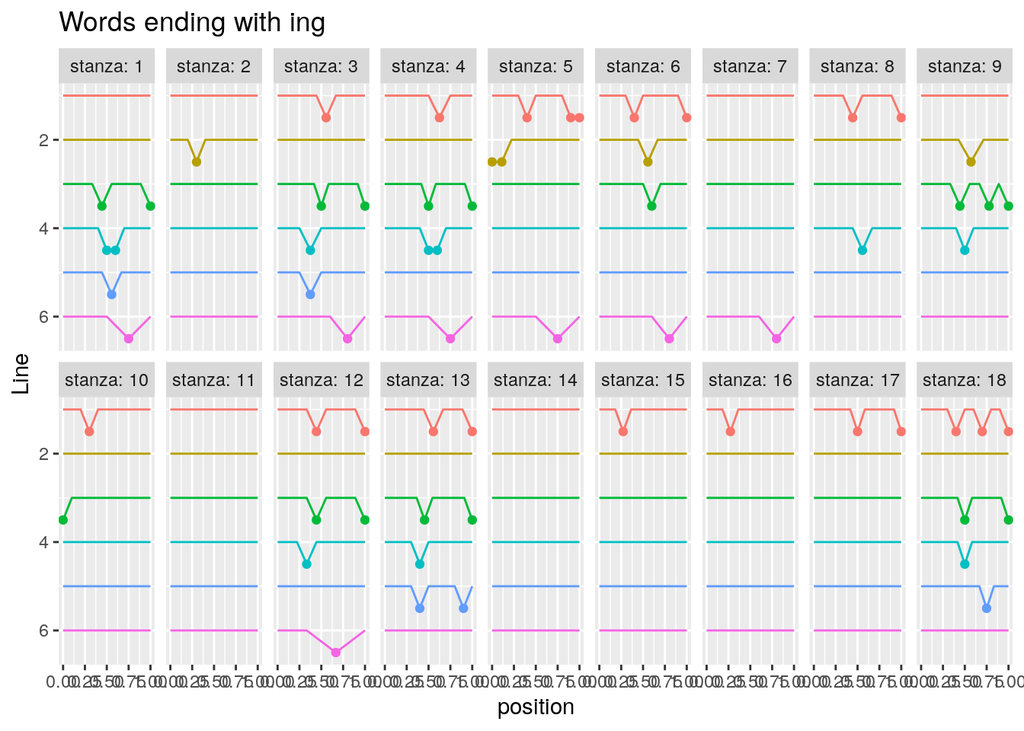

```r
ggplot(step5, aes(x = position, y = line + 0.5 * ing)) +
  geom_line(aes(group = line_no, color = factor(line))) +
  geom_point(data = filter(step5, ing), aes(color = factor(line))) +
  facet_wrap(~stanza, labeller = label_both, ncol = 9) +
  ylab("Line") +
  ggtitle("Words ending with ing") +
  guides(color = "none") +
  # Reverse the scale so that 1 is at the top
  scale_y_reverse()
```

It seems that there are alternating periods of activity and inactivity throughout this poem - lot so faction in the first part, a brief rest, then some more action in stanzas 8-9, a rest in 10-11, some action in 12-13, and a long rest before the final bit of activity at the end.

#### Theme: Religion and the afterlife

Here, we use the religious column (which is 0 if a word doesn’t have religious/afterlife connotations, and 1 if it does) to see if there are any patterns in where religious words show up.

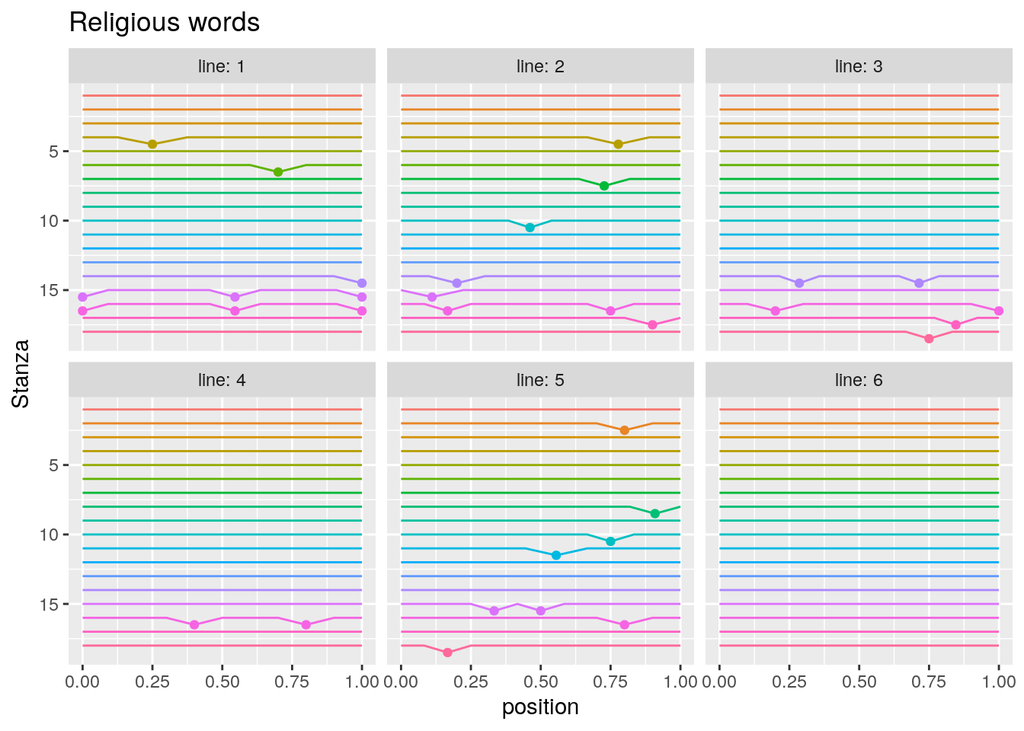

```r
ggplot(step5, aes(x = position, y = stanza + 0.5 * religious)) +
  geom_line(aes(group = line_no, color = factor(stanza))) +
  geom_point(data = filter(step5, religious), aes(color = factor(stanza))) +
  facet_wrap(~line, labeller = label_both) +
  ylab("Stanza") +
  ggtitle("Religious words") +
  guides(color = "none") +
  # Reverse the scale so that 1 is at the top
  scale_y_reverse()
```

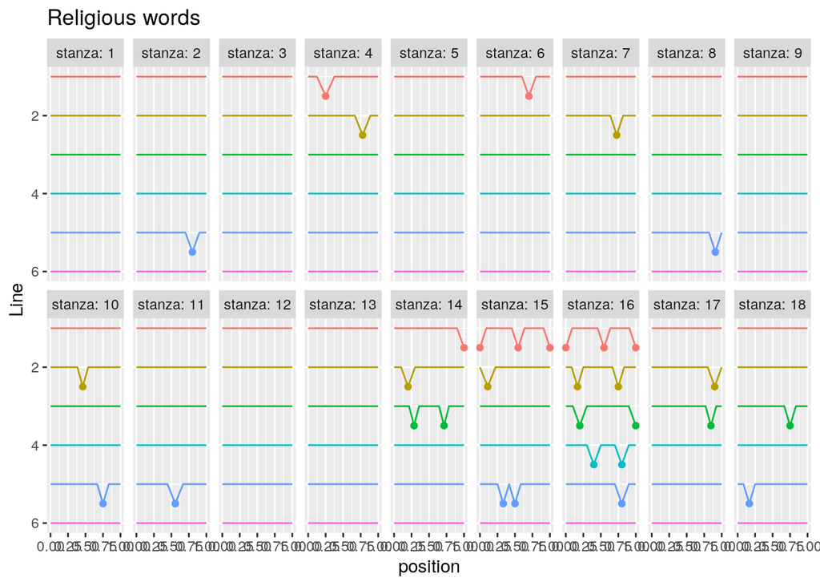

```r
ggplot(step5, aes(x = position, y = line + 0.5 * religious)) +
  geom_line(aes(group = line_no, color = factor(line))) +
  geom_point(data = filter(step5, religious), aes(color = factor(line))) +
  facet_wrap(~stanza, labeller = label_both, ncol = 9) +
  ylab("Line") +
  ggtitle("Religious words") +
  guides(color = "none") +
  # Reverse the scale so that 1 is at the top
  scale_y_reverse()
```

#### Theme: Knowledge

What about knowledge?

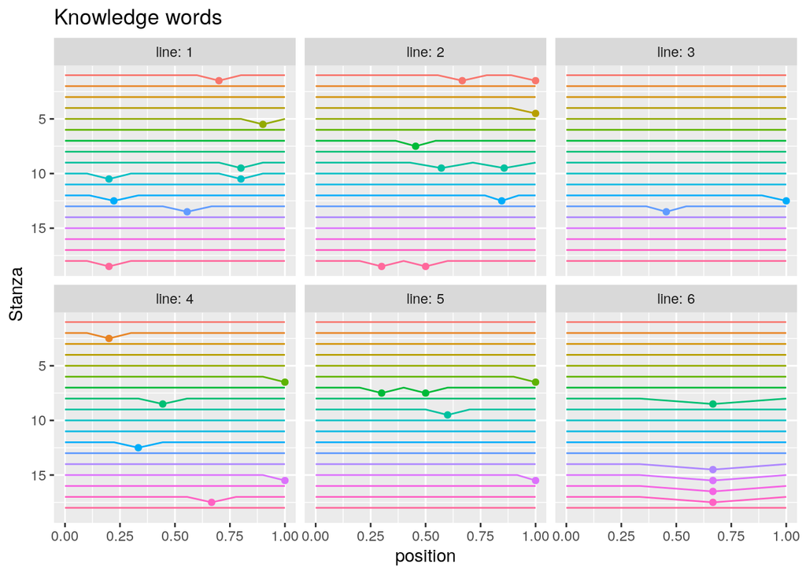

```r
ggplot(step5, aes(x = position, y = stanza + 0.5 * knowledge)) +
  geom_line(aes(group = line_no, color = factor(stanza))) +
  geom_point(data = filter(step5, knowledge), aes(color = factor(stanza))) +
  facet_wrap(~line, labeller = label_both) +
  ylab("Stanza") +
  ggtitle("Knowledge words") +
  guides(color = "none") +
  # Reverse the scale so that 1 is at the top
  scale_y_reverse()
```

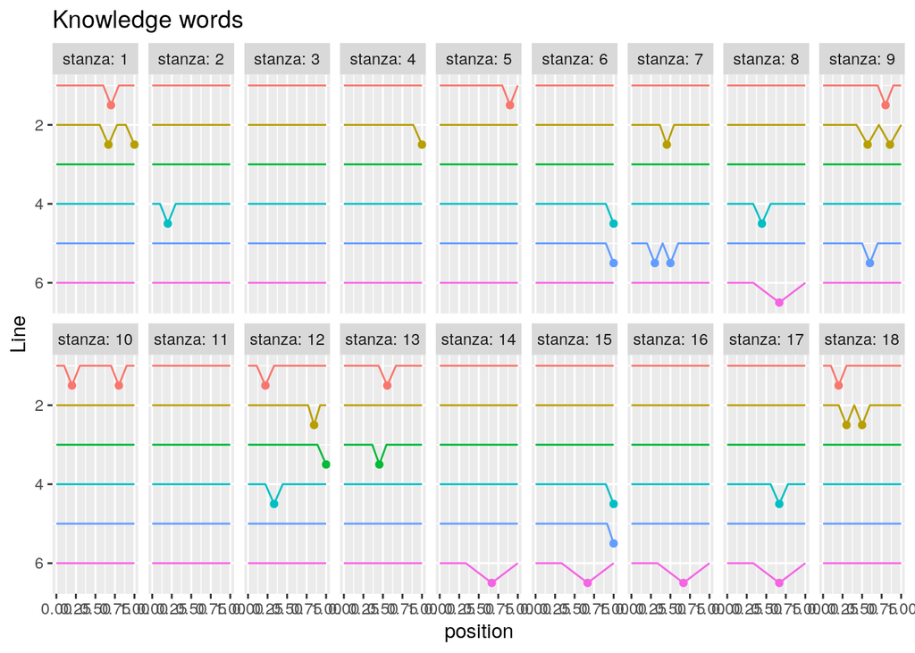

```r
ggplot(step5, aes(x = position, y = line + 0.5 * knowledge)) +
  geom_line(aes(group = line_no, color = factor(line))) +
  geom_point(data = filter(step5, knowledge), aes(color = factor(line))) +
  facet_wrap(~stanza, labeller = label_both, ncol = 9) +
  ylab("Line") +
  ggtitle("Knowledge words") +
  guides(color = "none") +
  # Reverse the scale so that 1 is at the top
  scale_y_reverse()
```

#### Theme: Knowledge vs. Religion

Some interpretations of this poem involve the author wrestling with the alternating pulls of rationality and irrationality. We obviously can’t get at actual context here (we’re only looking at single words, not constructed meaning) but lets see if the religion vs. knowledge thing holds up a bit, since I’m too lazy to define new regexes for irrationality and rationality.

The code to do this is a bit ugly - next week we’ll learn how to do this in a way that lets you actually have a key for the different word types. For now, circle = knowledge, x = religion reference.

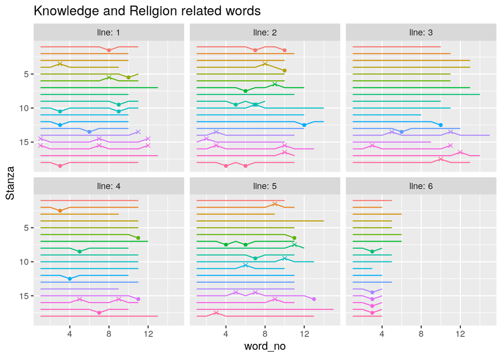

```r
ggplot(step5, aes(x = word_no, y = stanza + 0.5 * knowledge - 0.5 * religious)) +
  geom_line(aes(group = line_no, color = factor(stanza))) +
  geom_point(data = filter(step5, knowledge), aes(color = factor(stanza)), shape = 16) +
  geom_point(data = filter(step5, religious), aes(color = factor(stanza)), shape = 4) +
  facet_wrap(~line, labeller = label_both) +
  ylab("Stanza") +
  ggtitle("Knowledge and Religion related words") +
  guides(color = "none") +
  # Reverse the scale so that 1 is at the top
  scale_y_reverse()
```

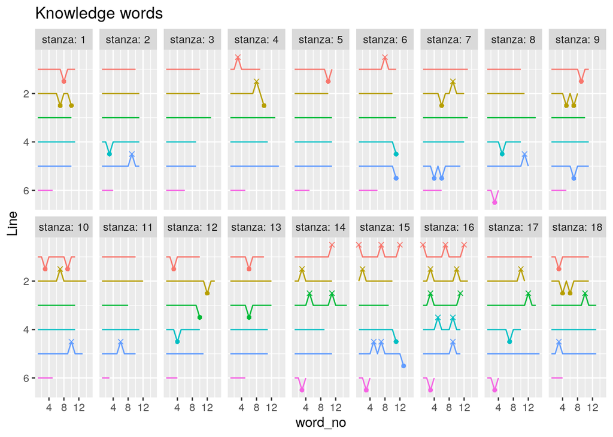

```r
ggplot(step5, aes(x = word_no, y = line + 0.5 * knowledge - 0.5 * religious)) +
  geom_line(aes(group = line_no, color = factor(line))) +
  geom_point(data = filter(step5, knowledge), aes(color = factor(line)), shape = 16) +
  geom_point(data = filter(step5, religious), aes(color = factor(line)), shape = 4) +
  facet_wrap(~stanza, labeller = label_both, ncol = 9) +
  ylab("Line") +
  ggtitle("Knowledge words") +
  guides(color = "none") +
  # Reverse the scale so that 1 is at the top
  scale_y_reverse()
```

#### Theme: Death

We can use the same idea with death-related words…

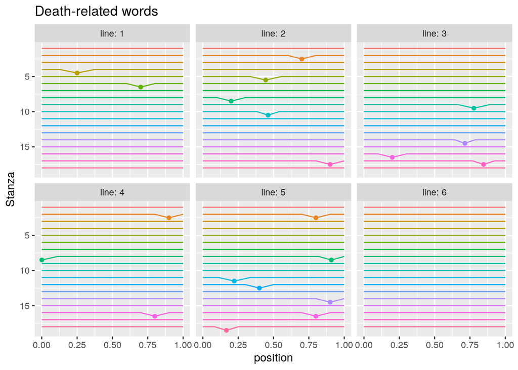

```r
ggplot(step5, aes(x = position, y = stanza + 0.5 * death)) +
  geom_line(aes(group = line_no, color = factor(stanza))) +
  geom_point(data = filter(step5, death), aes(color = factor(stanza))) +
  facet_wrap(~line, labeller = label_both) +
  ylab("Stanza") +
  ggtitle("Death-related words") +
  guides(color = "none") +
  # Reverse the scale so that 1 is at the top
  scale_y_reverse()
```

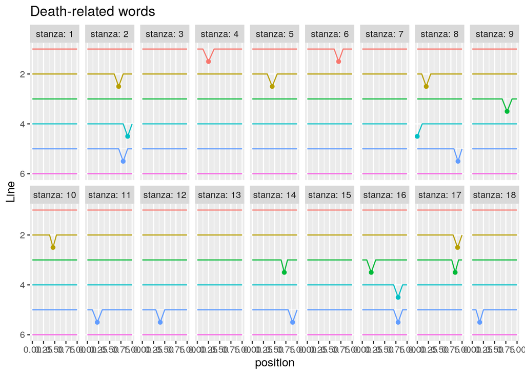

```r
ggplot(step5, aes(x = position, y = line + 0.5 * death)) +
  geom_line(aes(group = line_no, color = factor(line))) +
  geom_point(data = filter(step5, death), aes(color = factor(line))) +
  facet_wrap(~stanza, labeller = label_both, ncol = 9) +
  ylab("Line") +
  ggtitle("Death-related words") +
  guides(color = "none") +
  # Reverse the scale so that 1 is at the top
  scale_y_reverse()
```

I’m not sure how useful any of these are, but we can at least analyze them. In the first attempt through this problem over the summer, I looked at number of words in the line and was thinking it would be feasible to look at number of syllables in the line as well; now I’m wishing I could find an R package that would tell me where the emphasis is on each word – but so far I haven’t found much.

## Superstitions?

Five Thirty Eight published a story called [“Some people are too superstitious to have a baby on Friday the 13th”](http://fivethirtyeight.com/features/some-people-are-too-superstitious-to-have-a-baby-on-friday-the-13th/), and, along with the story, they published the data to [this github repo](https://github.com/fivethirtyeight/data/tree/master/births). Download one of the CSVs in the repository and read it into SAS.

1. Aggregate the data by month - is there any difference in the average number of births each month, across different months?

[output not shown]

2. Aggregate the data by day of the week. Are there any days of the week that are less likely to have births?
3. Compute the day of the year (so Feb 1 would be 32, June 25 would be 176 if the year isn’t a leap year, and 177 otherwise, and so on). What can you say about overall trends based on the day of the year? Are there any that would not be attributable to regular holidays, such as Memorial day, Labor Day, and Christmas? (Thanksgiving and Easter rotate around a bit more). Bonus points if you can figure out a macro that will compute this based on the year, month, and date.
4. Think through some way to numerically compare the births on Fridays (not the 13th) with births on Fridays that are the 13th. You can fit a model, compute means and subtract them – whatever you think is appropriate. I will evaluate you on your code and logic, not on your statistical skills.